# Estudio de la Relación Entre los Precios de Vivienda y sus Características de Propiedad Durante el Año 2019 en Lima

2023-06-05

```r
# Verificar si las librerías están instaladas y, en caso contrario, instalarlas
required_packages <- c("ggplot2", "dplyr", "readr","plotrix",'graphics')  # Lista de librerías requeridas
missing_packages <- setdiff(required_packages, installed.packages()[,"Package"])
if (length(missing_packages) > 0) {
  install.packages(missing_packages, dependencies = TRUE)
}
# Cargar las librerías
library(graphics)
library(readr)
library(dplyr)
library(ggplot2)
library(plotrix)
```

## 1. **INTRODUCCIÓN**

#### 1.1. **RELEVANCIA:**

El estudio de la relación entre los precios de vivienda y sus características en Lima durante el año 2019 es de gran importancia para el mercado inmobiliario y la toma de decisiones. Comprender cómo diferentes atributos afectan el valor de una vivienda proporciona información valiosa para evaluar su precio y desarrollar estrategias de inversión. Este estudio permite identificar tendencias y patrones, así como entender cómo factores como ubicación, tamaño, antigüedad y servicios influyen en los precios. Estos conocimientos son fundamentales para políticas públicas, planificación urbana y decisiones financieras en bienes raíces.

#### 1.2. **OBJETIVO:**

Analizar la relación entre los precios de vivienda y sus características de propiedad durante el año 2019 en Lima, con el fin de comprender los factores que influyen en la valoración de las propiedades en el mercado inmobiliario de la ciudad.

#### 1.2.1. **OBJETIVOS ESPECÍFICOS:**

- Identificar las principales características de propiedad que están asociadas con precios más altos de vivienda en Lima durante el año 2019.
- Evaluar la influencia de variables como el área total, la antigüedad, el número de dormitorios y baños, y la presencia de características especiales (piscina, amoblado, cocheras, etc.) en los precios de las viviendas.
- Analizar la variación de los precios de vivienda entre diferentes distritos de Lima durante el año 2019 y determinar si existen factores geográficos, como la ubicación o la proximidad a servicios, que expliquen estas diferencias.
- Comparar los precios y características de las propiedades residenciales y comerciales en Lima durante el año 2019, con el objetivo de identificar posibles diferencias en la valoración y determinar si el uso comercial agrega valor a las propiedades.
- Investigar la relación entre los precios de vivienda y el estado de la propiedad, como su estado de conservación o mantenimiento, y determinar si existe una relación significativa entre estos factores.

## 2. **MODO DE ORGANIZACIÓN**

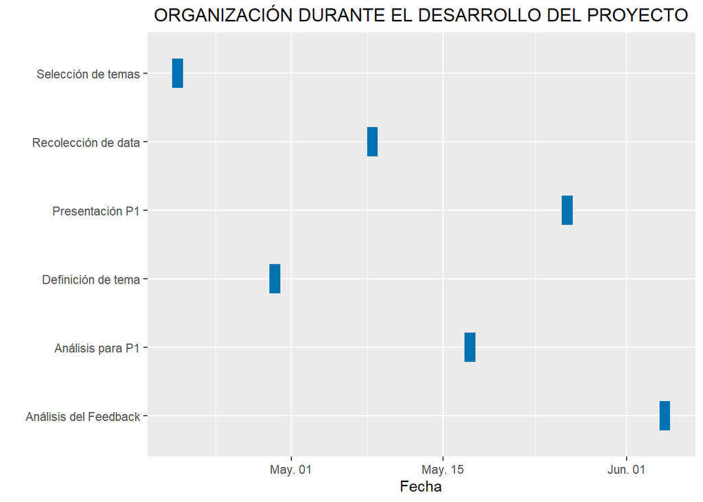

```r
datos <- data.frame(
  Tarea = c("Selección de temas", "Definición de tema", "Recolección de data", "Análisis para P1", "Presentación P1", "Análisis del Feedback"),
  Inicio = seq(as.Date("2023-04-20"), as.Date("2023-06-04"), length.out = 6),
  Fin = seq(as.Date("2023-04-20"), as.Date("2023-06-04"), length.out = 6) + 1
)

ggplot(datos, aes(y = Inicio, yend = Fin, x = Tarea, xend = Tarea)) +
  geom_segment(size = 10, color = "#0072B2") +
  labs(y = "Fecha", x = "") +
  ggtitle("ORGANIZACIÓN DURANTE EL DESARROLLO DEL PROYECTO") +
  scale_color_manual(values = c("#0072B2", "#004488", "#A6CEE3")) +  theme(plot.title = element_text(hjust = 0.5))+
coord_flip()
```

## 3. **DATOS**

#### 3.1. **RECOLECCIÓN DE DATOS:**

Los datos utilizados en este estudio fueron extraídos de una base de datos obtenida de la página Urbania.com, correspondiente al año 2019 en Lima, Perú. Esta base de datos ofrece información detallada sobre los precios de vivienda y diversas características de propiedad. Para acceder a la fuente original de los datos, se puede seguir el enlace proporcionado en Kaggle (https://www.kaggle.com/datasets/pbenavides/house-pricing-lima-peru?resource=download).

#### 3.2. **POBLACIÓN:**

El estudio se centra en todas las viviendas de Lima, especialmente en Lima Metropolitana, el principal centro urbano y económico del país. Esto proporciona una visión completa de los precios de vivienda y sus características en un entorno urbano y dinámico. Lima abarca una amplia y diversa área geográfica con diversos precios y atributos de propiedad, y cuenta con numerosas transacciones inmobiliarias y opciones de vivienda.

#### 3.3. **MUESTRA:**

La base de datos utilizada en este estudio proviene de las viviendas publicadas en la página Urbania.com. La base de datos consta de 7663 filas y 91 columnas, lo que proporciona una gran cantidad de información para analizar. Sin embargo, es importante tener en cuenta que la base de datos puede contener valores nulos, por lo que será necesario realizar una limpieza de datos antes de llevar a cabo el análisis. Esto asegurará que los resultados obtenidos sean confiables y precisos.

#### 3.4. **MUESTREO:**

Para llevar a cabo el muestreo de nuestro estudio, se utilizó un instrumento de recolección basado en un código de Python. Este código fue diseñado de manera que pudiera aprovechar métodos avanzados como Machine Learning, Web-Scraping y Programación Orientada a Objetos (POO) para cumplir con su función de manera eficiente y precisa. Los detalles técnicos y una descripción exhaustiva del código utilizado se encuentran disponibles en el siguiente enlace:(https://github.com/PBenavides/Automated-Valuation-Model-Lima)

#### 3.5. **VARIABLES:**

| Variable | Tipo | Descripción |
| --- | --- | --- |
| Precio | Numérica/Continua | Precio en soles |
| Dormitorios | Categórica/Ordinal | Cantidad de dormitorios |
| Antigüedad | Numérica/Continua | Años de antigüedad |
| Luminosidad | Categórica/Nominal | Que tan luminoso es |
| Tipo | Categórica/Nominal | Tipo de inmueble |
| Área_total_m2 | Numérica/Continua | Área total |
| Área_constr_m2 | Numérica/Continua | Área total construida |
| NroBanios | Numérica/Continua | Cantidad de baños |
| Estado de Inmueble | Categórica/Nominal | Estado de cuidado en que se encuentra el inmueble |
| Distrito | Categórica/Nominal | Distrito de Lima en que se ubica |
| Cocheras | Numérica/Discreta | Cantidad de cocheras |
| Uso_profesional | Categórica/Nominal | ¿Se le puede dar un uso tipo profesional? |
| Uso_comercial | Categórica/Nominal | ¿Se le puede dar un uso tipo comercial? |
| Nro_pisos | Numérica/Discreta | Cantidad de pisos |
| Piscina | Categórica/Nominal | Cantidad de piscinas |
| Amoblado | Categórica/Nominal | ¿Se encuentra amoblado? |

#### 3.6. **LIMPIEZA DE DATOS:**

```r
# Eliminar filas que no tienen "Lima" en la columna "Provincia"
urbania_data <- urbania_data %>% filter(Provincia == "Lima")
#Seleccionamos solo las variables que vamos a usar
columnas_usar = c("Precio", "Dormitorios", "Antiguedad", "Luminosidad", "Tipo", "Area_total_m2",'Area_constr_m2', "NroBanios", "Dormitorios", "Estado de Inmueble", "Distrito",'Cocheras','Uso_profesional','Uso_comercial','Nro_pisos','Piscina','Amoblado')
urbania_data <- urbania_data %>% select(all_of(columnas_usar))
# Eliminar filas con valores faltantes
urbania_data <- na.omit(urbania_data)
str(urbania_data)
```

```
## tibble [7,128 x 16] (S3: tbl_df/tbl/data.frame)
##  $ Precio            : num [1:7128] 885000 150000 1950000 380000 590000 380000 385000 75000 590000 64000 ...
##  $ Dormitorios       : chr [1:7128] "3" "5+" "4" "4" ...
##  $ Antiguedad        : num [1:7128] 5 5 3 1 4 1 3 5 6 1 ...
##  $ Luminosidad       : chr [1:7128] "Muy luminoso" "Muy luminoso" "Muy luminoso" "Muy luminoso" ...
##  $ Tipo              : chr [1:7128] "Casa" "Casa" "Casa" "Casa de Playa" ...
##  $ Area_total_m2     : num [1:7128] 600 183 1518 150 344 ...
##  $ Area_constr_m2    : num [1:7128] 450 350 625 150 290 300 270 173 600 173 ...
##  $ NroBanios         : num [1:7128] 4 5 5 5 4 5 5 5 5 2 ...
##  $ Estado de Inmueble: chr [1:7128] "Excelente" "Excelente" "Excelente" "Excelente" ...
##  $ Distrito          : chr [1:7128] "LaMolina" "Lurigancho" "LaMolina" "Asia" ...
##  $ Cocheras          : num [1:7128] 3 1 4 3 2 2 1 1 3 0 ...
##  $ Uso_profesional   : chr [1:7128] "NoEspecifica" "Si" "NoEspecifica" "NoEspecifica" ...
##  $ Uso_comercial     : chr [1:7128] "No" "Si" "NoEspecifica" "NoEspecifica" ...
##  $ Nro_pisos         : num [1:7128] 2 3 3 2 2 3 3 2 2 2 ...
##  $ Piscina           : chr [1:7128] "0" "NoEspecifica" "NoEspecifica" "1" ...
##  $ Amoblado          : chr [1:7128] "0" "0" "1" "1" ...
##  - attr(*, "na.action")= 'omit' Named int 4120
##   ..- attr(*, "names")= chr "4120"
```

```r
# Clasificación correcta de variables según su tipo
# Lista de columnas numéricas
urbania_data <- urbania_data %>%
  mutate(Luminosidad = factor(Luminosidad, levels = c("Muy luminoso", "Luminoso", "NoEspecifica")),
`Estado de Inmueble` = factor(`Estado de Inmueble`, levels = c("Excelente", "Muy bueno", "Bueno", "Remodelado", "A Remodelar", "NoEspecifica")))
# Eliminar valores atípicos en la columna "price"
urbania_data <- urbania_data[urbania_data$Area_total_m2 <= 5000, ]

Q1 <- quantile(urbania_data$Precio, 0.25)
Q3 <- quantile(urbania_data$Precio, 0.75)
Q1_area <- quantile(urbania_data$Area_total_m2, 0.25)
Q3_area <- quantile(urbania_data$Area_total_m2, 0.75)

IQR_area <- Q3_area - Q1_area
IQR <- Q3 - Q1

lower_limit <- Q1 - 1.5 * IQR
upper_limit <- Q3 + 1.5 * IQR
lower_limit_area <- Q1_area - 1.5 * IQR_area
upper_limit_area <- Q3_area + 1.5 * IQR_area

urbania_data <- urbania_data[urbania_data$Precio >= lower_limit & urbania_data$Precio <= upper_limit, ]
urbania_data <- urbania_data[urbania_data$Area_total_m2 >= lower_limit_area & urbania_data$Area_total_m2 <= upper_limit_area, ]
# Convertimos al precio en miles
urbania_data$Precio <- (urbania_data$Precio/10000)
# Guardar los datos limpios en un nuevo archivo CSV
write_csv(urbania_data, "urbania_data_clean.csv")
```

## 4. **ANÁLISIS DESCRIPTIVO**

### 4.1. **ANÁLISIS GENERAL:**

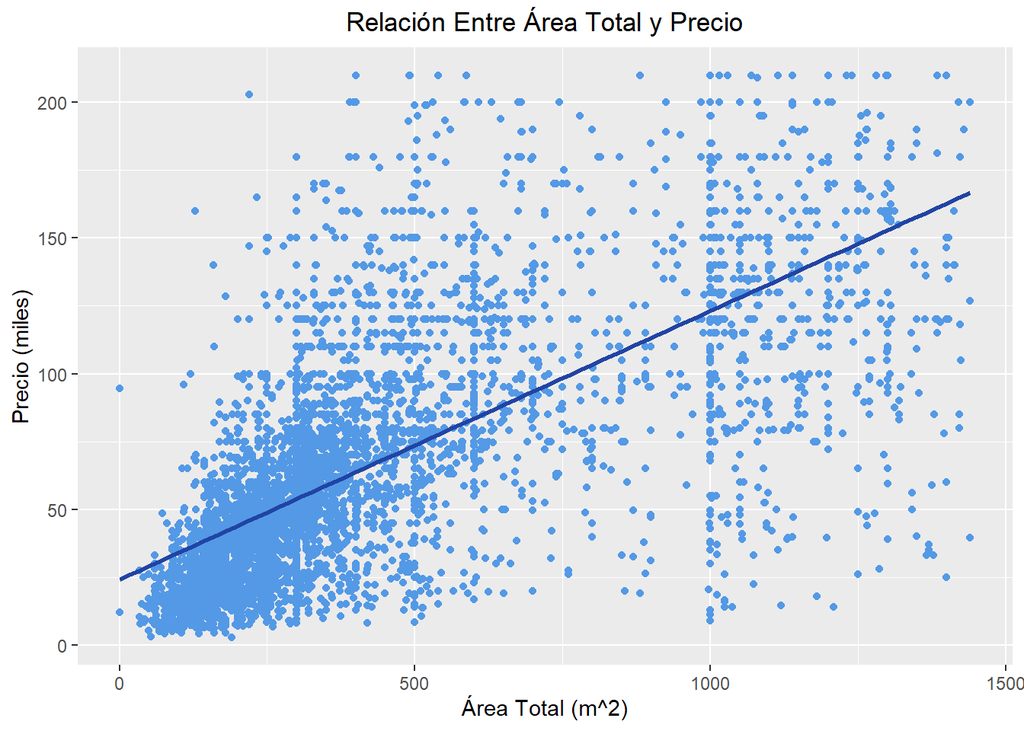

```r
# Diagrama de dispersión AREA TOTAL Y PRECIO
ggplot(urbania_data, aes(x = Area_total_m2, y = Precio)) +
  geom_point(color = "#5399E6") +
  geom_smooth(method = "lm", se = FALSE, color = "#2144A4") +
  labs(title = "Relación Entre Área Total y Precio", x = "Área Total (m^2)", y = "Precio (miles)") +
  theme(plot.title = element_text(hjust = 0.5)) +
  scale_color_manual(values = c("#5399E6", "#2144A4"))
```

```r
cor(urbania_data$Area_total_m2, urbania_data$Precio)
```

```
## [1] 0.7137099
```

- Un coeficiente de correlación de 0.7137099 indica una correlación positiva moderadamente fuerte entre el área total y el precio. A medida que aumenta el área total de una propiedad, es probable que su precio también aumente, pero no necesariamente de manera proporcional o lineal. La correlación de 0.71 indica que hay una tendencia general de crecimiento en el precio a medida que aumenta el área total, pero otros factores también pueden influir en el precio de manera independiente.

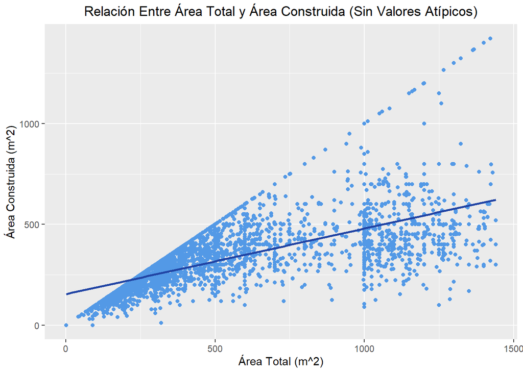

```r
# Filtrar los datos eliminando los valores atípicos
filtered_data <- urbania_data %>%
  filter(Area_constr_m2 >= lower_limit & Area_constr_m2 <= upper_limit & Area_constr_m2 <= Area_total_m2)
# Generar el diagrama de dispersión con los datos filtrados
ggplot(filtered_data, aes(x = Area_total_m2, y = Area_constr_m2)) +
  geom_point(color = "#5399E6") +
  geom_smooth(method = "lm", se = FALSE, color = "#2144A4") +
  labs(title = "Relación Entre Área Total y Área Construida (Sin Valores Atípicos)",
       x = "Área Total (m^2)", y = "Área Construida (m^2)") +
  theme(plot.title = element_text(hjust = 0.5)) +
  scale_color_manual(values = c("#5399E6", "#2144A4"))
```

```r
# Filtrar los datos eliminando los valores atípicos
filtered_data <- urbania_data %>%
  filter(Area_constr_m2 <= Area_total_m2)
# Calcular la correlación entre el área total y el área construida
cor(filtered_data$Area_total_m2, filtered_data$Area_constr_m2)
```

```
## [1] 0.7125446
```

- En el análisis, se realizó una modificación para asegurar que el área construida no sea mayor que el área total, eliminando datos atípicos. Se encontró una correlación positiva moderada de 0.7125446 entre el área construida y el área total, lo que sugiere que hay una relación positiva entre ambas variables. A medida que aumenta el área total de una propiedad, es probable que también aumente el área construida, y viceversa. Sin embargo, es importante destacar que esta correlación no implica una relación lineal perfecta ni establece una relación causal entre las variables.

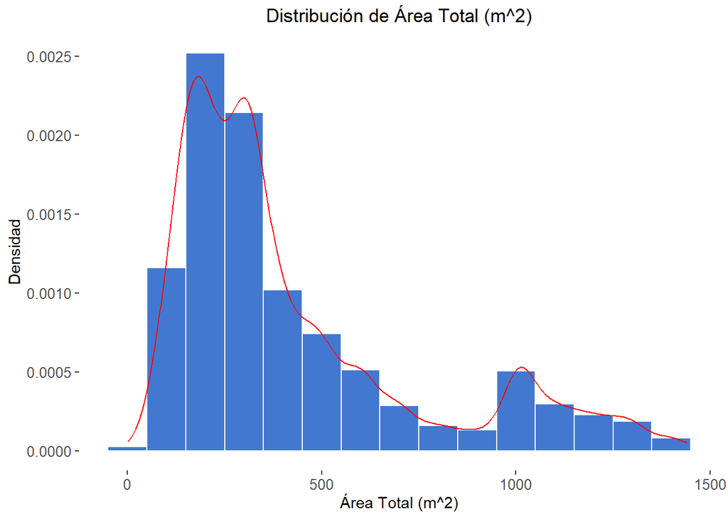

```r
#Histograma AREA TOTAL
ggplot(urbania_data, aes(x = Area_total_m2)) +
  geom_histogram(aes(y = ..density..),binwidth = 100, fill = "#4378D0" , color = "white") +
  geom_density(color = "red") +
  labs(title = "Distribución de Área Total (m^2)", x = "Área Total (m^2)", y = "Densidad") +
  theme(plot.title = element_text(hjust = 0.5),
        axis.text = element_text(size = 10),
        panel.background = element_rect(fill = "white"),
        panel.grid.major = element_blank(),
        panel.grid.minor = element_blank(),
        panel.border = element_blank())
```

```r
# Cálculo de la media
media_area <- round(mean(urbania_data$Area_total_m2), 2)
# Cálculo de la desviación estándar
desviacion_area <- round(sd(urbania_data$Area_total_m2), 2)
# Valor mínimo y máximo
minimo_area <- min(urbania_data$Area_total_m2)
maximo_area <- max(urbania_data$Area_total_m2)
# Imprimir los resultados
media_area
```

```
## [1] 428.36
```

```r
desviacion_area
```

```
## [1] 323.19
```

```r
minimo_area
```

```
## [1] 1
```

```r
maximo_area
```

```
## [1] 1440
```

- El histograma muestra la distribución del atributo “Área Total (m^2)” en el conjunto de datos. La forma de la distribución es asimétrica positiva, con la mayoría de las propiedades concentradas en áreas pequeñas y unas pocas propiedades con áreas muy grandes. Esto indica que hay una considerable variabilidad en las áreas de las propiedades. La media de 428.36 metros cuadrados y la desviación estándar de 323.19 confirman esta interpretación, mostrando la dispersión alrededor de la media.

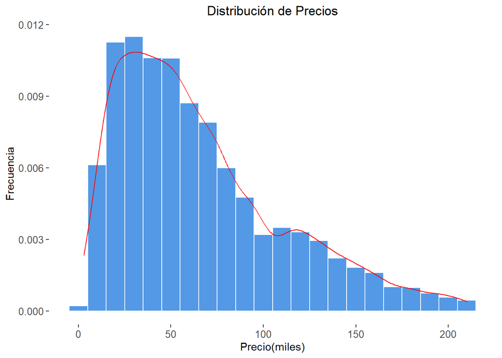

```r
#Histograma PRECIO
ggplot(urbania_data, aes(x = Precio)) +
  geom_histogram(aes(y = ..density..),binwidth = 10, fill = "#5399E6" , color = "white") +
  geom_density(color = "red") +
  labs(title = "Distribución de Precios", x = "Precio(miles)", y = "Frecuencia") +
  theme(plot.title = element_text(hjust = 0.5),
        axis.text = element_text(size = 10),
        panel.background = element_rect(fill = "white"),
        panel.grid.major = element_blank(),
        panel.grid.minor = element_blank(),
        panel.border = element_blank())
```

```r
# Cálculo de la media del precio
mean(urbania_data$Precio)
```

```
## [1] 66.52858
```

```r
# Cálculo de la desviación estándar del precio
sd(urbania_data$Precio)
```

```
## [1] 44.84329
```

```r
# Valor mínimo y máximo del precio
min(urbania_data$Precio)
```

```
## [1] 2.9
```

```r
max(urbania_data$Precio)
```

```
## [1] 210
```

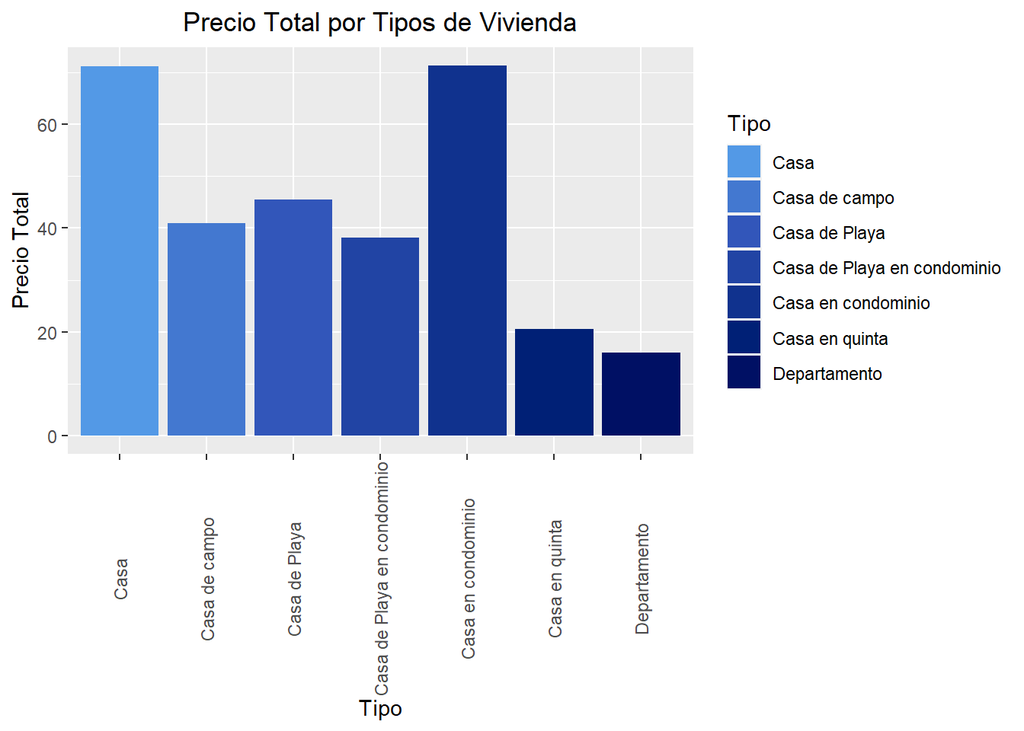

```r
#Gráfico de barras PRECIO-TIPO
totalP <- urbania_data %>% group_by(Tipo) %>%
  summarise(PT = mean(Precio))
ggplot(totalP, aes(x = Tipo, y = PT, fill = Tipo)) +
  geom_bar(stat = "identity") +
  labs(title = "Precio Total por Tipos de Vivienda", x = "Tipo", y = "Precio Total") +
  theme(axis.text.x = element_text(angle = 90, vjust = 0.5)) +
  theme(plot.title = element_text(hjust = 0.5)) +
  scale_fill_manual(values = c("#5399E6", "#4378D0", "#3256BA", "#2144A4", "#10328E", "#002076", "#001064"))
```

```r
totalP
```

```
## # A tibble: 7 x 2
##   Tipo                           PT
##   <chr>                       <dbl>
## 1 Casa                         71.1
## 2 Casa de Playa                45.5
## 3 Casa de Playa en condominio  38.1
## 4 Casa de campo                40.9
## 5 Casa en condominio           71.3
## 6 Casa en quinta               20.6
## 7 Departamento                 16
```

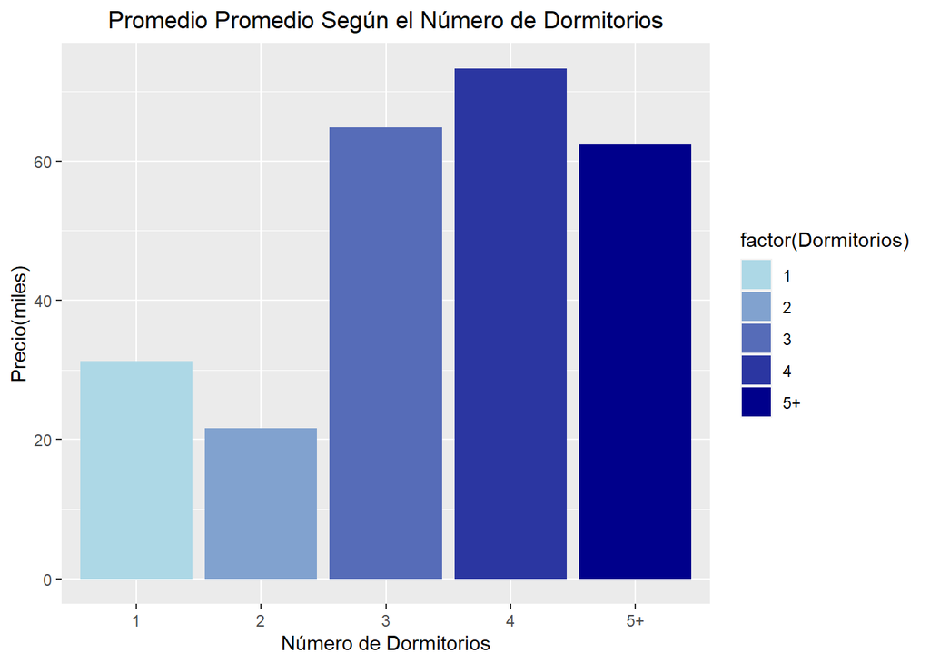

```r
#Gráfico de barras DORMITORIOS-PRECIO
NDor <- urbania_data %>%
  group_by(Dormitorios) %>%
  summarise(PRECIO= mean(Precio))
# Crear la paleta de colores azules
colors <- colorRampPalette(c("lightblue", "darkblue"))(length(levels(factor(NDor$Dormitorios))))
# Crear el gráfico de barras en tonos azules
ggplot(NDor, aes(x = factor(Dormitorios), y = PRECIO, fill = factor(Dormitorios))) +
  geom_bar(stat = "identity") +
  labs(title = "Promedio Promedio Según el Número de Dormitorios", x = "Número de Dormitorios", y = "Precio(miles)") +
  theme(plot.title = element_text(hjust = 0.5)) +
  scale_fill_manual(values = colors)
```

```r
# Cálculo de la variabilidad de precios dentro de cada grupo de dormitorios
# Agrupar los datos por dormitorios y calcular las medidas de dispersión
variability <- urbania_data %>%
  group_by(Dormitorios) %>%
  summarise(
    Rango = max(Precio) - min(Precio),
    Desviacion_estandar = sd(Precio),
    Coeficiente_variacion = sd(Precio) / mean(Precio) * 100
  )
# Mostrar los resultados
variability
```

```
## # A tibble: 5 x 4
##   Dormitorios Rango Desviacion_estandar Coeficiente_variacion
##   <chr>       <dbl>               <dbl>                 <dbl>
## 1 1            159.                42.7                 137.
## 2 2            125.                21.3                  98.2
## 3 3            207.                45.4                  70.0
## 4 4            206.                44.6                  60.8
## 5 5+           206.                43.6                  69.9
```

- El gráfico de barras y los resultados del análisis de variabilidad nos muestran que los precios de las propiedades varían dentro de cada grupo de dormitorios. Los grupos de mayor número de dormitorios tienden a tener una mayor dispersión de precios, mientras que los grupos de menor número de dormitorios muestran una mayor variabilidad en relación con la media. Estos resultados resaltan la importancia de considerar el número de dormitorios al analizar y comparar los precios de las propiedades.

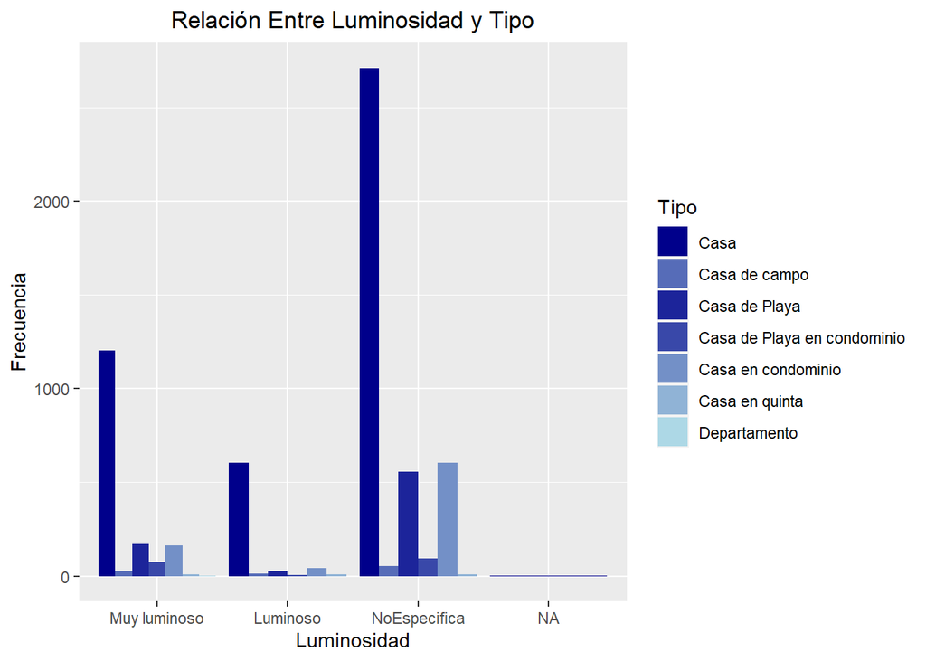

```r
#Gráfico de barras agrupadas LUMINOSISDAD-TIPO
# Obtener los niveles únicos de Tipo en urbania_dataf
urbania_dataf <- urbania_data %>%
  count(Luminosidad, Tipo, name = "Frecuencia")
unique_tipos <- unique(urbania_dataf$Tipo)
# Crear la paleta de colores con la longitud adecuada
colors <- colorRampPalette(c("darkblue", "lightblue"))(length(unique_tipos))
# Crear el gráfico de barras agrupadas sin el sector "NoEspecifica"
ggplot(urbania_dataf, aes(x = Luminosidad, y = Frecuencia, fill = Tipo)) +
  geom_bar(stat = "identity", position = "dodge") +
  labs(title = "Relación Entre Luminosidad y Tipo", x = "Luminosidad", y = "Frecuencia") +
  scale_fill_manual(values = setNames(colors, unique_tipos)) +
  theme(plot.title = element_text(hjust = 0.5))
```

```r
urbania_dataf
```

```
## # A tibble: 20 x 3
##    Luminosidad  Tipo                        Frecuencia
##    <fct>        <chr>                            <int>
##  1 Muy luminoso Casa                              1205
##  2 Muy luminoso Casa de Playa                      170
##  3 Muy luminoso Casa de Playa en condominio         74
##  4 Muy luminoso Casa de campo                       29
##  5 Muy luminoso Casa en condominio                 163
##  6 Muy luminoso Casa en quinta                       8
##  7 Muy luminoso Departamento                         1
##  8 Luminoso     Casa                               606
##  9 Luminoso     Casa de Playa                       29
## 10 Luminoso     Casa de Playa en condominio          7
## 11 Luminoso     Casa de campo                       14
## 12 Luminoso     Casa en condominio                  44
## 13 Luminoso     Casa en quinta                      10
## 14 NoEspecifica Casa                              2712
## 15 NoEspecifica Casa de Playa                      556
## 16 NoEspecifica Casa de Playa en condominio         94
## 17 NoEspecifica Casa de campo                       54
## 18 NoEspecifica Casa en condominio                 605
## 19 NoEspecifica Casa en quinta                       8
## 20 <NA>         Casa                                 2
```

- La luminosidad parece tener una influencia en la distribución de los diferentes tipos de propiedad. El nivel de luminosidad “Muy luminoso” muestra una mayor variabilidad en las frecuencias, mientras que el nivel de luminosidad “Luminoso” muestra una variabilidad algo menor. Estos datos nos proporcionan información sobre las características comunes y la variabilidad asociada con cada nivel de luminosidad en relación con los diferentes tipos de propiedad.

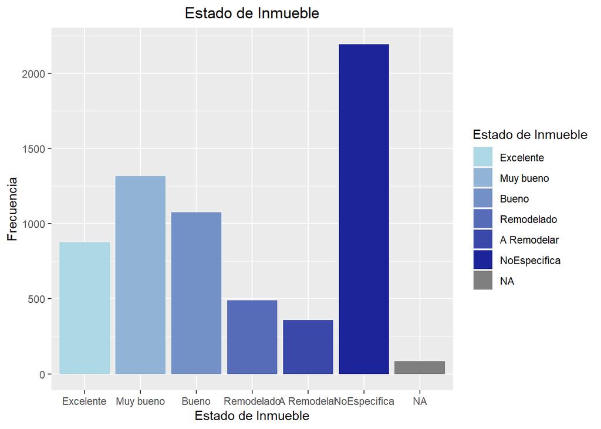

```r
colors <- colorRampPalette(c("lightblue", "darkblue"))(length(unique(urbania_data$`Estado de Inmueble`)))

# Crear el histograma en tonos azules
ggplot(data = urbania_data, aes(x = `Estado de Inmueble`, fill = `Estado de Inmueble`)) +
  geom_bar() +
  labs(title = "Estado de Inmueble", x = "Estado de Inmueble", y = "Frecuencia") +
  theme(plot.title = element_text(hjust = 0.5)) +
  scale_fill_manual(values = colors)
```

```r
summary(urbania_data$`Estado de Inmueble`)
```

```
##    Excelente    Muy bueno        Bueno   Remodelado  A Remodelar NoEspecifica
##          875         1316         1075          488          358         2194
##         NA's
##           85
```

- El gráfico muestra la distribución de los estados de los inmuebles mencionados por las personas. Se observa que muchas personas optaron por no mencionar el estado de su inmueble, lo que podría indicar falta de información o preferencia por no revelar esta información. Entre aquellos que sí mencionaron el estado, la categoría más frecuente es “Muy bueno”. Sin embargo, debemos ser cautelosos al interpretar estos resultados, ya que podría existir un sesgo debido a que las personas tienden a calificar positivamente sus propiedades. Es importante considerar que el estado real de los inmuebles puede variar y que se requiere una evaluación más detallada y objetiva para obtener una comprensión precisa de los estados de los inmuebles en cuestión.

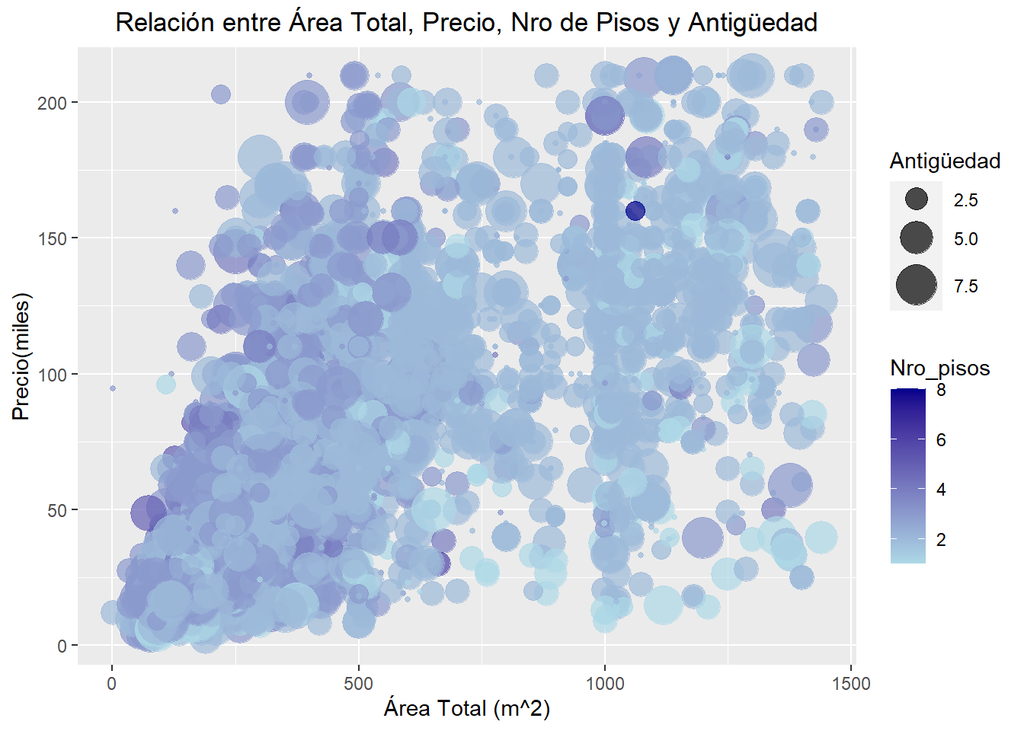

```r
#gráfico de burbujas AREA TOTAL- PRECIO - NUMERO DE PISOS - ANTIGUEDAD
# Crear el gráfico de burbujas en diferentes tonos de azul
ggplot(data = urbania_data, aes(x = Area_total_m2, y = Precio, size = Antiguedad, color = Nro_pisos)) +
  geom_point(alpha = 0.7) +
  scale_size_continuous(range = c(1, 10)) +
  scale_color_gradient(low = "lightblue", high = "darkblue") +
  labs(title = "Relación entre Área Total, Precio, Nro de Pisos y Antigüedad", x = "Área Total (m^2)", y = "Precio(miles)", size = "Antigüedad") +
  theme(plot.title = element_text(hjust = 0.5))
```

```r
# Cálculo de la media del área total
mean_area_total <- round(mean(urbania_data$Area_total_m2), 2)
print(paste("Media del área total:", mean_area_total))
```

```
## [1] "Media del área total: 428.36"
```

```r
# Cálculo de la desviación estándar del área total
sd_area_total <- round(sd(urbania_data$Area_total_m2), 2)
print(paste("Desviación estándar del área total:", sd_area_total))
```

```
## [1] "Desviación estándar del área total: 323.19"
```

```r
# Valor mínimo y máximo del área total
min_area_total <- round(min(urbania_data$Area_total_m2), 2)
max_area_total <- round(max(urbania_data$Area_total_m2), 2)
print(paste("Valor mínimo del área total:", min_area_total))
```

```
## [1] "Valor mínimo del área total: 1"
```

```r
print(paste("Valor máximo del área total:", max_area_total))
```

```
## [1] "Valor máximo del área total: 1440"
```

```r
# Cálculo de la media del precio
mean_precio <- round(mean(urbania_data$Precio), 2)
print(paste("Media del precio:", mean_precio))
```

```
## [1] "Media del precio: 66.53"
```

```r
# Cálculo de la desviación estándar del precio
sd_precio <- round(sd(urbania_data$Precio), 2)
print(paste("Desviación estándar del precio:", sd_precio))
```

```
## [1] "Desviación estándar del precio: 44.84"
```

```r
# Valor mínimo y máximo del precio
min_precio <- round(min(urbania_data$Precio), 2)
max_precio <- round(max(urbania_data$Precio), 2)
print(paste("Valor mínimo del precio:", min_precio))
```

```
## [1] "Valor mínimo del precio: 2.9"
```

```r
print(paste("Valor máximo del precio:", max_precio))
```

```
## [1] "Valor máximo del precio: 210"
```

```r
# Frecuencia de cada número de pisos
freq_nro_pisos <- table(urbania_data$Nro_pisos)
print("Frecuencia de cada número de pisos:")
```

```
## [1] "Frecuencia de cada número de pisos:"
```

```r
print(freq_nro_pisos)
```

```
##
##    1    2    3    4    5    6    7    8
##  414 3549 2237  167   17    5    1    1
```

```r
# Cálculo de la media de la antigüedad
mean_antiguedad <- round(mean(urbania_data$Antiguedad), 2)
print(paste("Media de la antigüedad:", mean_antiguedad))
```

```
## [1] "Media de la antigüedad: 3.07"
```

```r
# Cálculo de la desviación estándar de la antigüedad
sd_antiguedad <- round(sd(urbania_data$Antiguedad), 2)
print(paste("Desviación estándar de la antigüedad:", sd_antiguedad))
```

```
## [1] "Desviación estándar de la antigüedad: 1.89"
```

```r
# Valor mínimo y máximo de la antigüedad
min_antiguedad <- round(min(urbania_data$Antiguedad), 2)
max_antiguedad <- round(max(urbania_data$Antiguedad), 2)
print(paste("Valor mínimo de la antigüedad:", min_antiguedad))
```

```
## [1] "Valor mínimo de la antigüedad: 1"
```

```r
print(paste("Valor máximo de la antigüedad:", max_antiguedad))
```

```
## [1] "Valor máximo de la antigüedad: 9"
```

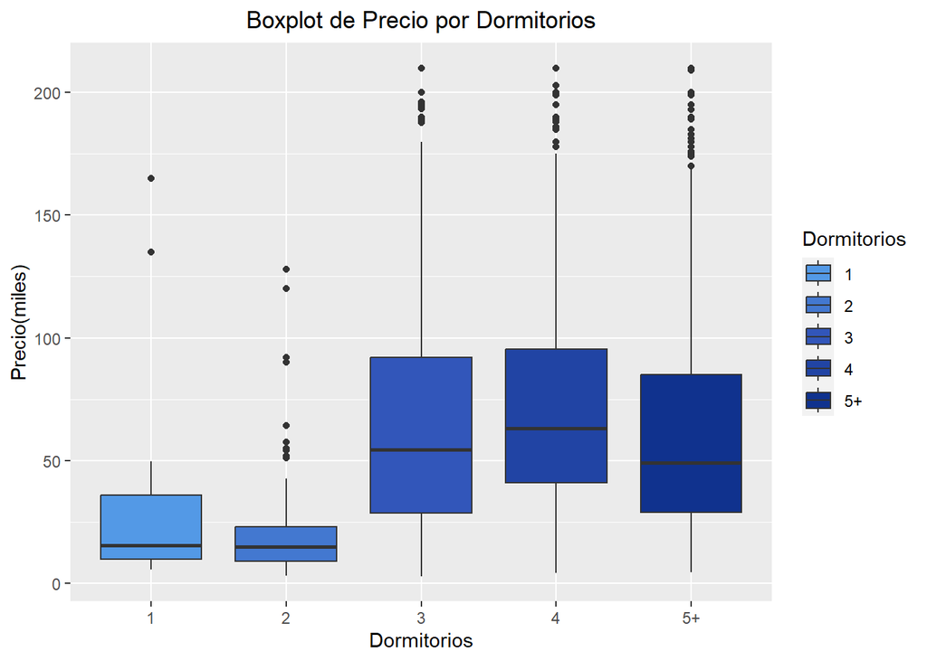

```r
#Box plot indexado PRECIO-DORMITORIOS
ggplot(urbania_data) +
  geom_boxplot(aes(x = Dormitorios, y = Precio, fill = Dormitorios)) +
  labs(title = "Boxplot de Precio por Dormitorios", x = "Dormitorios", y = "Precio(miles)") +
  scale_fill_manual(values = c("#5399E6", "#4378D0", "#3256BA", "#2144A4", "#10328E", "#002076", "#001064")) +
  theme(plot.title = element_text(hjust = 0.5))
```

```r
# Estadísticas descriptivas para cada grupo de dormitorios
stats <- urbania_data %>%
  group_by(Dormitorios) %>%
  summarise(
    Mediana = median(Precio),
    Cuartil_1 = quantile(Precio, 0.25),
    Cuartil_3 = quantile(Precio, 0.75),
    Valor_Minimo = min(Precio),
    Valor_Maximo = max(Precio))
stats
```

```
## # A tibble: 5 x 6
##   Dormitorios Mediana Cuartil_1 Cuartil_3 Valor_Minimo Valor_Maximo
##   <chr>         <dbl>     <dbl>     <dbl>        <dbl>        <dbl>
## 1 1              15.4      9.75      35.8          5.6          165
## 2 2              14.9      9         23            3.1          128
## 3 3              54.5     28.5       92            2.9          210
## 4 4              63       41         95.2          4.2          210
## 5 5+             49       29         85            4.5          210
```